# Tucson’s Vanishing Winters

Watch the Blues Fade and Reds Take Over

Author

Vanishree Venkatachalapathy

Published

March 18, 2026

## Introduction

Tucson, Arizona sits in the Sonoran Desert — a city where summer heat is a given, but where mild winters have long been part of the landscape’s character. Over the past four decades, that balance has quietly shifted.

This project draws on 41 years of monthly NASA satellite temperature data (1984–2024) to map exactly how and when that shift occurred. Rather than a single global baseline, each month is compared against its own 41-year average — so a warm January is judged on January’s terms, not July’s. The result is a clear signal: the blue of cool, below-average months is fading, and the red of anomalous warmth is spreading across more months, more seasons, and more years.

> **Data:** NASA POWER Agroclimatology API · Monthly mean 2-metre air temperature (T2M) · Tucson, AZ (32.22°N, 110.97°W) · 1984–2024

## Methodology

The analysis follows a four-step pipeline: load packages, retrieve data from the NASA POWER API, reshape to long format, and compute per-month anomalies. All code is reproducible — expand any block below to inspect a step.

### Packages & Dependencies

```r
library(nasapower)   # NASA POWER API client — get_power()
library(dplyr)       # Data wrangling
library(tidyr)       # pivot_longer, pivot_wider
library(lubridate)   # Date handling — make_date()
library(jsonlite)    # toJSON() — bridge R data to JavaScript
library(htmltools)   # tagList, tags$*, browsable() — embed HTML/JS in Quarto
library(ggplot2)     # Static visualizations
library(ggtext)      # element_markdown() for rich text in ggplot2 titles
library(glue)        # String interpolation for annotations
library(knitr)       # kable() for summary tables
library(scales)      # Label formatting in ggplot2
library(here)        # Project-relative file paths
```

### Data Source

Monthly mean 2-metre air temperature for Tucson, Arizona was retrieved from the NASA POWER agroclimatology API, covering the full 41-year period 1984–2024.

```r
data_file <- here("data", "tucson_T2M_monthly_1984-2024.csv")

if (file.exists(data_file)) {
  raw <- read.csv(data_file)
} else {
  raw <- get_power(
    community    = "ag",
    lonlat       = c(-110.97, 32.22),
    pars         = "T2M",
    dates        = c("1984-01-01", "2024-12-31"),
    temporal_api = "monthly"
  )
  write.csv(raw, data_file, row.names = FALSE)
}

# Preview the raw API response structure
head(raw, 14) |> kable(caption = "Raw NASA POWER response (first 14 rows)")
```

Raw NASA POWER response (first 14 rows)

| LON | LAT | PARAMETER | YEAR | JAN | FEB | MAR | APR | MAY | JUN | JUL | AUG | SEP | OCT | NOV | DEC | ANN |
| --- | --- | --- | --- | --- | --- | --- | --- | --- | --- | --- | --- | --- | --- | --- | --- | --- |
| -110.97 | 32.22 | T2M | 1984 | 8.63 | 10.19 | 14.37 | 16.36 | 26.22 | 27.06 | 26.69 | 26.18 | 24.98 | 16.66 | 12.67 | 8.95 | 18.27 |
| -110.97 | 32.22 | T2M | 1985 | 7.06 | 8.74 | 12.61 | 19.24 | 23.20 | 29.65 | 29.47 | 28.30 | 23.22 | 18.94 | 12.43 | 9.77 | 18.60 |
| -110.97 | 32.22 | T2M | 1986 | 12.24 | 12.19 | 15.68 | 18.54 | 23.61 | 28.93 | 27.80 | 27.87 | 23.84 | 18.67 | 13.41 | 9.02 | 19.35 |
| -110.97 | 32.22 | T2M | 1987 | 7.93 | 9.96 | 11.64 | 19.00 | 21.57 | 28.82 | 28.79 | 26.82 | 24.40 | 21.59 | 11.98 | 7.47 | 18.37 |
| -110.97 | 32.22 | T2M | 1988 | 8.36 | 11.90 | 13.67 | 17.35 | 22.61 | 28.83 | 28.81 | 27.72 | 24.46 | 21.92 | 13.09 | 8.19 | 18.93 |
| -110.97 | 32.22 | T2M | 1989 | 7.69 | 12.02 | 16.55 | 21.96 | 24.07 | 28.62 | 29.89 | 27.25 | 26.39 | 19.57 | 13.96 | 9.47 | 19.82 |
| -110.97 | 32.22 | T2M | 1990 | 8.43 | 9.20 | 13.89 | 18.74 | 22.10 | 29.73 | 27.32 | 25.14 | 25.18 | 20.01 | 13.41 | 8.28 | 18.49 |
| -110.97 | 32.22 | T2M | 1991 | 8.68 | 12.42 | 10.58 | 16.38 | 20.85 | 26.47 | 29.02 | 27.85 | 24.98 | 21.09 | 12.47 | 9.16 | 18.36 |
| -110.97 | 32.22 | T2M | 1992 | 7.26 | 10.96 | 12.37 | 19.46 | 22.86 | 27.27 | 28.20 | 27.29 | 26.14 | 21.09 | 11.09 | 8.36 | 18.54 |
| -110.97 | 32.22 | T2M | 1993 | 9.70 | 9.32 | 13.71 | 17.94 | 23.08 | 27.89 | 28.09 | 27.74 | 25.10 | 19.58 | 12.33 | 9.29 | 18.70 |
| -110.97 | 32.22 | T2M | 1994 | 9.80 | 9.98 | 14.19 | 17.84 | 22.34 | 30.01 | 30.08 | 29.50 | 26.51 | 18.79 | 10.90 | 9.13 | 19.14 |
| -110.97 | 32.22 | T2M | 1995 | 8.06 | 12.83 | 13.72 | 15.72 | 19.85 | 26.57 | 30.54 | 29.69 | 26.62 | 21.57 | 16.06 | 10.93 | 19.38 |
| -110.97 | 32.22 | T2M | 1996 | 10.84 | 13.36 | 14.04 | 19.51 | 24.92 | 29.95 | 29.60 | 28.39 | 24.34 | 19.19 | 13.81 | 10.28 | 19.87 |
| -110.97 | 32.22 | T2M | 1997 | 9.48 | 10.14 | 16.67 | 17.15 | 25.98 | 27.37 | 29.96 | 28.46 | 27.34 | 19.07 | 14.38 | 6.88 | 19.46 |

### Data Preparation

We reshape the wide API response to long format, one row per (year, month) observation, and construct a proper `date` column for time-series plotting.

```r
monthly <- raw |>
  dplyr::select(year = YEAR, JAN, FEB, MAR, APR, MAY, JUN,
                JUL, AUG, SEP, OCT, NOV, DEC) |>
  tidyr::pivot_longer(
    cols      = JAN:DEC,
    names_to  = "month_abb",
    values_to = "temp"
  ) |>
  mutate(
    month = match(tolower(month_abb), tolower(month.abb)),
    date  = lubridate::make_date(year, month, 1L)
  ) |>
  dplyr::select(date, year, month, temp) |>
  arrange(date)

# Confirm: should be exactly 492 rows (41 years × 12 months)
cat("Total observations:", nrow(monthly), "\n")
```

```
Total observations: 492
```

```r
cat("Date range:", format(min(monthly$date)), "to", format(max(monthly$date)), "\n")
```

```
Date range: 1984-01-01 to 2024-12-01
```

### Temperature Anomaly Calculation

Each month’s anomaly is its observed temperature minus that **month’s own** 41-year mean. This preserves the seasonal structure of the signal: a warm January is judged against January’s average, so no month is unfairly penalized or rewarded by comparison to a different season.

```r
# Per-month baseline: each of the 12 months gets its own 41-year mean
monthly_baseline <- monthly |>
  group_by(month) |>
  summarise(baseline_temp = mean(temp, na.rm = TRUE), .groups = "drop")

# Anomaly = observed temp minus that month's baseline
monthly_anomaly <- monthly |>
  left_join(monthly_baseline, by = "month") |>
  mutate(anomaly = temp - baseline_temp) |>
  dplyr::select(year, month, temp, baseline_temp, anomaly)

# Export anomaly data to JSON — injected into the JavaScript particle field
# as ANOMALY_DATA: an array of {year, month, anomaly} objects (492 rows total)
anomaly_json <- jsonlite::toJSON(
  monthly_anomaly |> dplyr::select(year, month, anomaly),
  dataframe = "rows",
  digits    = 4
)

# Summary table: per-month baselines
monthly_baseline |>
  mutate(month_name = month.abb[month]) |>
  dplyr::select(Month = month_name, `Baseline Mean Temp (°C)` = baseline_temp) |>
  kable(
    caption = "41-year per-month baseline temperatures, Tucson AZ (1984–2024)",
    digits  = 2
  )
```

41-year per-month baseline temperatures, Tucson AZ (1984–2024)

| Month | Baseline Mean Temp (°C) |
| --- | --- |
| Jan | 9.65 |
| Feb | 11.09 |
| Mar | 14.30 |
| Apr | 18.36 |
| May | 23.32 |
| Jun | 28.89 |
| Jul | 29.33 |
| Aug | 28.39 |
| Sep | 26.12 |
| Oct | 20.57 |
| Nov | 14.23 |
| Dec | 9.68 |

The overall warming signal becomes clear when we summarise at the annual level:

```r
# Collapse 492 monthly anomalies to one mean anomaly per year (41 rows)
annual_summary <- monthly_anomaly |>
  group_by(year) |>
  summarise(
    mean_anomaly = mean(anomaly, na.rm = TRUE),
    .groups = "drop"
  )

cat("Total warming (mean anomaly first vs last decade):\n")
```

```
Total warming (mean anomaly first vs last decade):
```

```r
early <- mean(annual_summary$mean_anomaly[annual_summary$year <= 1993]) # first decade mean
late  <- mean(annual_summary$mean_anomaly[annual_summary$year >= 2015]) # last decade mean
cat(glue("  1984–1993 mean anomaly: {round(early, 2)}°C\n"))
```

```
1984–1993 mean anomaly: -0.78°C
```

```r
cat(glue("  2015–2024 mean anomaly: {round(late,  2)}°C\n"))
```

```
2015–2024 mean anomaly: 0.84°C
```

```r
cat(glue("  Shift: +{round(late - early, 2)}°C\n"))
```

```
Shift: +1.62°C
```

```r
hottest  <- annual_summary |> slice_max(mean_anomaly, n = 1)
coolest  <- annual_summary |> slice_min(mean_anomaly, n = 1)
cat(glue("\nHottest year:  {hottest$year}  (+{round(hottest$mean_anomaly,  2)}°C)\n"))
```

```
Hottest year:  2017  (+1.62°C)
```

```r
cat(glue("Coolest year:  {coolest$year}  ({round(coolest$mean_anomaly, 2)}°C)\n"))
```

```
Coolest year:  1998  (-1.34°C)
```

```r
# Export hottest/coolest for JS annotation in particle field
hottest_json <- jsonlite::toJSON(list(year=hottest$year, anom=round(hottest$mean_anomaly,2)), auto_unbox=TRUE)
coolest_json <- jsonlite::toJSON(list(year=coolest$year, anom=round(coolest$mean_anomaly,2)), auto_unbox=TRUE)
```

## The Warming Signal

Four complementary views of the same 41-year record. Together they build the case before the interactive visualization: Tucson is warming, it is accelerating, and it is happening across every season.

### Warming Stripes

One stripe per year, colored by its annual mean temperature anomaly. No axes, no numbers — just the pattern. Read it left to right.

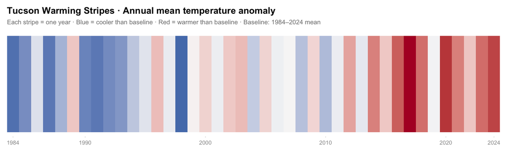

```r
annual_summary |>
  ggplot(aes(x = year, y = 1, fill = mean_anomaly)) +
  geom_col(width = 1, show.legend = FALSE) +
  scale_fill_gradient2(
    low      = "#2166ac",
    mid      = "#f7f7f7",
    high     = "#b2182b",
    midpoint = 0
  ) +
  scale_x_continuous(
    breaks = c(1984, 1990, 2000, 2010, 2020, 2024),
    expand = c(0, 0)
  ) +
  theme_void() +
  theme(
    axis.text.x  = element_text(color = "grey60", size = 8, margin = margin(t = 4)),
    axis.ticks.x = element_line(color = "grey60"),
    plot.title   = element_markdown(size = 13, face = "bold", margin = margin(b = 6)),
    plot.subtitle = element_text(size = 9, color = "grey50", margin = margin(b = 8)),
    plot.margin  = margin(10, 10, 10, 10)
  ) +
  labs(
    title    = "**Tucson Warming Stripes** · Annual mean temperature anomaly",
    subtitle = "Each stripe = one year · Blue = cooler than baseline · Red = warmer than baseline · Baseline: 1984–2024 mean"
  )
```

The pattern is stark. Before 2000, blue dominated the timeline. After 2012, warm anomalies have been nearly unbroken — only a handful of years since then register below the long-term baseline.

### Annual Anomaly Trend

Annual mean anomalies shown as bars, with a LOESS smoother overlaid to reveal the underlying trend. The hottest and coolest years are annotated directly on the chart.

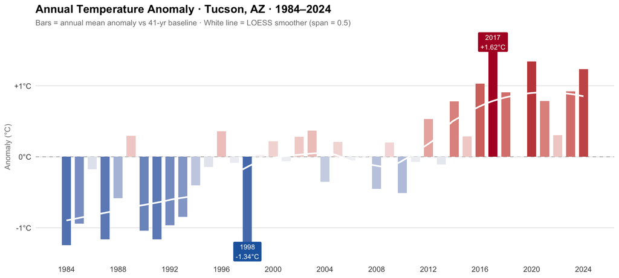

```r
hottest_label <- annual_summary |> slice_max(mean_anomaly, n = 1)
coolest_label <- annual_summary |> slice_min(mean_anomaly, n = 1)

annual_summary |>
  ggplot(aes(x = year, y = mean_anomaly)) +
  geom_hline(yintercept = 0, color = "grey70", linewidth = 0.4, linetype = "dashed") +
  geom_col(aes(fill = mean_anomaly), width = 0.7, show.legend = FALSE) +
  geom_smooth(method = "loess", span = 0.5, se = FALSE,
              color = "white", linewidth = 0.9, linetype = "solid") +
  geom_label(
    data  = hottest_label,
    aes(label = glue("{year}\n+{round(mean_anomaly,2)}°C")),
    size  = 2.8, fill = "#b2182b", color = "white",
    label.padding = unit(0.3, "lines"), label.size = 0
  ) +
  geom_label(
    data  = coolest_label,
    aes(label = glue("{year}\n{round(mean_anomaly,2)}°C")),
    size  = 2.8, fill = "#2166ac", color = "white",
    label.padding = unit(0.3, "lines"), label.size = 0
  ) +
  scale_fill_gradient2(low = "#2166ac", mid = "#f7f7f7", high = "#b2182b", midpoint = 0) +
  scale_x_continuous(breaks = seq(1984, 2024, by = 4)) +
  scale_y_continuous(labels = function(x) paste0(ifelse(x > 0, "+", ""), x, "°C")) +
  theme_minimal(base_size = 11) +
  theme(
    panel.grid.minor  = element_blank(),
    panel.grid.major.x = element_blank(),
    plot.title        = element_markdown(size = 13, face = "bold"),
    plot.subtitle     = element_text(size = 9, color = "grey50"),
    axis.title        = element_text(size = 9, color = "grey50")
  ) +
  labs(
    title    = "**Annual Temperature Anomaly** · Tucson, AZ · 1984–2024",
    subtitle = "Bars = annual mean anomaly vs 41-yr baseline · White line = LOESS smoother (span = 0.5)",
    x        = NULL,
    y        = "Anomaly (°C)"
  )
```

The LOESS smoother reveals a persistent upward trajectory. The warmest years on record cluster almost entirely in the most recent decade — a signal of accelerating, not merely steady, change.

### Monthly Heat Calendar

Each cell is one (month, year) combination. Reading down a column shows how an entire year’s months compare to baseline; reading across a row shows how a particular month has trended over time.

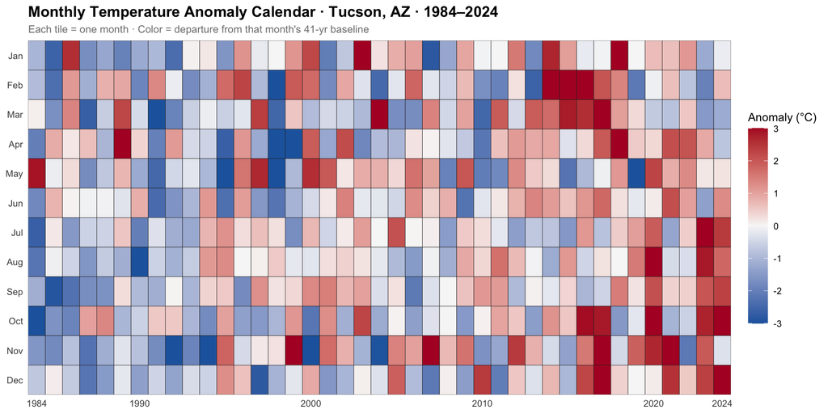

```r
monthly_anomaly |>
  mutate(month_fct = factor(month.abb[month], levels = rev(month.abb))) |>
  ggplot(aes(x = year, y = month_fct, fill = anomaly)) +
  geom_tile(color = "grey15", linewidth = 0.15) +
  scale_fill_gradient2(
    low      = "#2166ac",
    mid      = "#f7f7f7",
    high     = "#b2182b",
    midpoint = 0,
    name     = "Anomaly (°C)",
    limits   = c(-3, 3),
    oob      = scales::squish
  ) +
  scale_x_continuous(
    breaks = c(1984, 1990, 2000, 2010, 2020, 2024),
    expand = c(0, 0)
  ) +
  scale_y_discrete(expand = c(0, 0)) +
  theme_minimal(base_size = 10) +
  theme(
    panel.grid    = element_blank(),
    legend.position = "right",
    legend.key.height = unit(1.2, "cm"),
    plot.title    = element_markdown(size = 13, face = "bold"),
    plot.subtitle = element_text(size = 9, color = "grey50"),
    axis.text.y   = element_text(size = 8)
  ) +
  labs(
    title    = "**Monthly Temperature Anomaly Calendar** · Tucson, AZ · 1984–2024",
    subtitle = "Each tile = one month · Color = departure from that month's 41-yr baseline",
    x        = NULL,
    y        = NULL
  )
```

Read down any recent year’s column and red has spread well beyond the summer months into spring and autumn. The cool blue winters that once anchored the calendar are becoming increasingly rare.

### Monthly Warming Rose

[figure not shown]

```r
monthly_anomaly |>
  group_by(month) |>
  summarise(mean_anom = mean(anomaly, na.rm = TRUE), .groups = "drop") |>
  mutate(
    month_name = factor(month.abb[month], levels = month.abb)
  ) |>
  ggplot(aes(x = month_name, y = mean_anom, fill = mean_anom)) +
  geom_col(width = 0.85, show.legend = FALSE) +
  geom_hline(yintercept = 0, color = "grey50", linewidth = 0.3) +
  coord_polar(start = -pi/12) +
  scale_fill_gradient2(low = "#2166ac", mid = "#f7f7f7", high = "#b2182b", midpoint = 0) +
  scale_y_continuous(labels = function(x) paste0(ifelse(x > 0, "+", ""), round(x, 1), "°C")) +
  theme_minimal(base_size = 11) +
  theme(
    panel.grid.major.x = element_line(color = "grey85", linewidth = 0.3),
    panel.grid.minor   = element_blank(),
    axis.text.x        = element_text(size = 9, face = "bold"),
    axis.text.y        = element_text(size = 7, color = "grey60"),
    axis.title         = element_blank(),
    plot.title         = element_markdown(size = 13, face = "bold", hjust = 0.5),
    plot.subtitle      = element_text(size = 9, color = "grey50", hjust = 0.5)
  ) +
  labs(
    title    = "**Monthly Warming Rose** · Tucson, AZ · 1984–2024",
    subtitle = "Petal length = mean anomaly for that calendar month across all 41 years"
  )
```

## Explore 41 Years of Tucson Temperatures

The visualization below encodes all 492 month–year combinations simultaneously as a living particle field. Each column of particles is a year (1984–2024, left to right). Each row is a calendar month (January at top, December at bottom). A particle’s **color** shows whether that month ran warmer or cooler than its 41-year average:

- **Red** — warmer than baseline
- **Blue** — cooler than baseline
- **Amber** — a warm anomaly in a summer month (June–August)

**Use the slider** at the bottom to scrub through years and highlight a column. **Hover over a month row** to inspect it and read the exact anomaly value in the stat box. Press **▶** to animate through all 41 years.

```r
# ── Output path ────────────────────────────────────────────────────────────
out_dir  <- here("output")
out_file <- file.path(out_dir, "tucson-vanishing-winters-interactive.html")
dir.create(out_dir, recursive = TRUE, showWarnings = FALSE)

# ── Build the HTML string (used for both embed + standalone file) ──────────
# anomaly_json was computed in Section 4 via jsonlite::toJSON()
particle_html_str <- paste0(
'
<!DOCTYPE html>
<html lang="en">
<head>
<meta charset="utf-8">
<title>Tucson \u00b7 Month \u00d7 Year Particle Field \u00b7 1984\u20132024</title>
<style>
* { margin:0; padding:0; box-sizing:border-box; }
body { background:#07070e; font-family:\'Georgia\',serif; overflow:hidden; }
canvas { display:block; position:absolute; top:0; left:0; }
#wrap { position:relative; width:100%; }
#border-frame {
  position:fixed; top:0; left:0; right:0; bottom:0;
  border:1px solid rgba(220,200,155,0.35);
  pointer-events:none; z-index:999;
}
#header {
  position:absolute; top:0; left:0; right:0; z-index:20;
  background:rgba(7,7,14,0.93);
  border-bottom:1px solid rgba(220,200,155,0.07);
  padding:9px 20px;
  display:flex; align-items:center; justify-content:space-between; gap:16px;
}
#header .title-block { display:flex; flex-direction:column; gap:1px; white-space:nowrap; }
#header .title-main { font-size:22px; font-weight:700; color:rgba(220,200,160,0.92); letter-spacing:0.01em; line-height:1.1; margin:0; }
#header .title-sub  { font-size:10px; font-style:italic; color:rgba(220,200,160,0.82); letter-spacing:0.04em; margin-top:1px; margin-bottom:0; }
#header .desc  { font-size:10px; color:rgba(220,200,160,0.82); line-height:1.5; text-align:center; flex:1; }
#header .keys  { display:flex; gap:14px; white-space:nowrap; }
#header .keys span {
  font-size:10px; letter-spacing:0.1em; text-transform:uppercase;
  display:flex; align-items:center; gap:6px; color:rgba(220,200,160,0.82);
}
#header .keys span::before { content:\'\'; width:18px; height:2.5px; border-radius:1px; flex-shrink:0; }
.k-warm::before { background:#e05530; }
.k-cool::before { background:#5588e0; }
.k-sum::before  { background:#e8a020; }
#ui {
  position:absolute; bottom:0; left:0; right:0; z-index:20;
  padding:8px 22px 12px;
  background:linear-gradient(transparent, rgba(7,7,14,0.97) 36%);
  display:flex; align-items:center; gap:18px;
}
.stat { text-align:center; min-width:90px; }
.stat .val { font-size:14px; font-weight:700; }
.stat .lbl { font-size:10px; letter-spacing:0.12em; text-transform:uppercase; color:rgba(220,200,160,0.82); margin-top:2px; line-height:1.4; }
#slider-wrap { flex:1; display:flex; flex-direction:column; gap:4px; }
#slider-wrap label { font-size:10px; letter-spacing:0.13em; text-transform:uppercase; color:rgba(220,200,160,0.82); text-align:center; }
input[type=range] {
  width:100%; height:4px; cursor:pointer;
  -webkit-appearance:none; appearance:none; border-radius:2px; outline:none; border:none;
  background:linear-gradient(to right,#1a3388,#882211);
}
input[type=range]::-webkit-slider-thumb {
  -webkit-appearance:none; width:14px; height:14px; border-radius:50%;
  background:#c8b080; border:2px solid rgba(220,195,150,0.5); cursor:pointer;
}
#play-btn {
  width:38px; height:38px; border-radius:50%; flex-shrink:0;
  background:rgba(7,7,14,0.6);
  border:1.5px solid rgba(220,200,160,0.5);
  color:rgba(220,200,160,0.88); font-size:14px;
  cursor:pointer; display:flex; align-items:center; justify-content:center;
  transition:border-color 0.2s, color 0.2s;
}
#play-btn:hover { border-color:rgba(220,200,160,0.9); color:rgba(255,240,200,1); }
#bar-panel {
  position:absolute; left:0; right:0; z-index:15;
  background:rgba(7,7,14,0.88);
  border-top:1px solid rgba(220,200,155,0.07);
  border-bottom:1px solid rgba(220,200,155,0.06);
}
#bar-c { display:block; width:100%; }
#month-gutter {
  position:absolute; left:0; z-index:18;
  width:48px;
  background:linear-gradient(to right, rgba(7,7,14,0.97) 70%, rgba(7,7,14,0));
  display:flex; flex-direction:column; pointer-events:none;
}
#month-gutter .m-label {
  display:flex; align-items:center;
  padding-left:8px;
  font-family:\'Georgia\',serif;
  font-size:11px;
  color:rgba(220,200,160,0.88);
  letter-spacing:0.04em;
  flex-shrink:0;
  transition: font-size 0.15s ease, color 0.15s ease;
}
</style>
</head>
<body>
<div id="border-frame"></div>
<div id="wrap">
  <canvas id="c" role="img" aria-label="Interactive particle field of Tucson temperature anomalies 1984-2024. Each column of particles is a year; each row is a calendar month. Color shows anomaly versus the 41-year per-month baseline: blue for cooler-than-average, red for warmer-than-average. The field shifts from predominantly blue on the left (1980s-1990s) to predominantly red on the right (2010s-2024), showing accelerating warming.">Interactive particle field: Tucson monthly temperature anomalies 1984-2024. Use the year slider and hover over month rows to explore the data.</canvas>
  <div id="month-gutter">
    <div class="m-label">Jan</div>
    <div class="m-label">Feb</div>
    <div class="m-label">Mar</div>
    <div class="m-label">Apr</div>
    <div class="m-label">May</div>
    <div class="m-label">Jun</div>
    <div class="m-label">Jul</div>
    <div class="m-label">Aug</div>
    <div class="m-label">Sep</div>
    <div class="m-label">Oct</div>
    <div class="m-label">Nov</div>
    <div class="m-label">Dec</div>
  </div>
  <div id="bar-panel">
    <canvas id="bar-c" role="img" aria-label="Bar chart showing the mean temperature anomaly for each of the 12 calendar months in the currently selected year. Bars are red for warmer-than-average months and blue for cooler-than-average months, relative to each month 41-year baseline. Updates as the year slider moves.">Monthly anomaly bar chart for the selected year. Updates as you move the year slider.</canvas>
  </div>
  <div id="header">
    <div class="title-block">
      <h1 class="title-main">Tucson\u2019s Vanishing Winters</h1>
      <h2 class="title-sub">Watch the Blues Fade and Reds Take Over</h2>
    </div>
    <div class="desc">
      Y-axis = month of year (Jan at top \u2192 Dec at bottom) \u00b7 X-axis = year (1984 \u2192 2024)<br>
      Each particle sits in its month row and year column \u00b7 color = temperature anomaly vs 41-yr baseline
    </div>
    <div class="keys">
      <span class="k-warm">Warmer than baseline</span>
      <span class="k-cool">Cooler than baseline</span>
      <span class="k-sum">Summer peak (Jun\u2013Aug)</span>
    </div>
  </div>
  <div id="ui">
    <button id="play-btn" title="Play / Pause">\u25b6</button>
    <div id="slider-wrap">
      <label>\u25c4 drag to highlight a year \u25ba</label>
      <input type="range" id="slider" min="1984" max="2024" value="1984" step="1">
      <label id="yr-lbl" style="color:rgba(220,200,160,0.88); font-size:10px; letter-spacing:0.1em;">
        Year: 1984 \u2014 hover a month row to inspect
      </label>
    </div>
    <div class="stat">
      <div class="val" id="stat-anom" style="color:#e05530">\u2014</div>
      <div class="lbl">Anomaly for<br>highlighted cell</div>
    </div>
  </div>
</div>
<script>
// ── Data bridge: R exports these via jsonlite::toJSON(), injected here as JS constants ──
const ANOMALY_DATA = ',
anomaly_json,
'; // array of {year, month, anomaly} — 492 rows (41 years × 12 months)
const HOTTEST = ',
hottest_json,
'; // {year, anom} — used to annotate the hottest year column
const COOLEST = ',
coolest_json,
'; // {year, anom} — used to annotate the coolest year column
```